# Risk Factor Analysis

## Outcome Variable

**Outcome Variable:** ever_sstunted

## Predictor Variables

**Intervention Variable:** hhwealth_quart

**Adjustment Set:**

unadjusted

## Stratifying Variables

The analysis was stratified on these variable(s):

- agecat
- studyid
- country

## Data Summary

| agecat | studyid | country | hhwealth_quart | ever_sstunted | n_cell | n |
| --- | --- | --- | --- | --- | --- | --- |
| 0-24 months | COHORTS | GUATEMALA | Wealth Q4 | 0 | 291 | 1278 |
| 0-24 months | COHORTS | GUATEMALA | Wealth Q4 | 1 | 194 | 1278 |
| 0-24 months | COHORTS | GUATEMALA | Wealth Q1 | 0 | 112 | 1278 |
| 0-24 months | COHORTS | GUATEMALA | Wealth Q1 | 1 | 133 | 1278 |
| 0-24 months | COHORTS | GUATEMALA | Wealth Q2 | 0 | 117 | 1278 |
| 0-24 months | COHORTS | GUATEMALA | Wealth Q2 | 1 | 143 | 1278 |
| 0-24 months | COHORTS | GUATEMALA | Wealth Q3 | 0 | 154 | 1278 |
| 0-24 months | COHORTS | GUATEMALA | Wealth Q3 | 1 | 134 | 1278 |
| 0-24 months | COHORTS | PHILIPPINES | Wealth Q4 | 0 | 635 | 3057 |
| 0-24 months | COHORTS | PHILIPPINES | Wealth Q4 | 1 | 208 | 3057 |
| 0-24 months | COHORTS | PHILIPPINES | Wealth Q1 | 0 | 416 | 3057 |
| 0-24 months | COHORTS | PHILIPPINES | Wealth Q1 | 1 | 271 | 3057 |
| 0-24 months | COHORTS | PHILIPPINES | Wealth Q2 | 0 | 331 | 3057 |
| 0-24 months | COHORTS | PHILIPPINES | Wealth Q2 | 1 | 211 | 3057 |
| 0-24 months | COHORTS | PHILIPPINES | Wealth Q3 | 0 | 586 | 3057 |
| 0-24 months | COHORTS | PHILIPPINES | Wealth Q3 | 1 | 399 | 3057 |
| 0-6 months | COHORTS | GUATEMALA | Wealth Q4 | 0 | 353 | 1037 |
| 0-6 months | COHORTS | GUATEMALA | Wealth Q4 | 1 | 29 | 1037 |
| 0-6 months | COHORTS | GUATEMALA | Wealth Q1 | 0 | 171 | 1037 |
| 0-6 months | COHORTS | GUATEMALA | Wealth Q1 | 1 | 26 | 1037 |
| 0-6 months | COHORTS | GUATEMALA | Wealth Q2 | 0 | 185 | 1037 |
| 0-6 months | COHORTS | GUATEMALA | Wealth Q2 | 1 | 20 | 1037 |
| 0-6 months | COHORTS | GUATEMALA | Wealth Q3 | 0 | 223 | 1037 |
| 0-6 months | COHORTS | GUATEMALA | Wealth Q3 | 1 | 30 | 1037 |
| 0-6 months | COHORTS | PHILIPPINES | Wealth Q4 | 0 | 806 | 3057 |
| 0-6 months | COHORTS | PHILIPPINES | Wealth Q4 | 1 | 37 | 3057 |
| 0-6 months | COHORTS | PHILIPPINES | Wealth Q1 | 0 | 632 | 3057 |
| 0-6 months | COHORTS | PHILIPPINES | Wealth Q1 | 1 | 55 | 3057 |
| 0-6 months | COHORTS | PHILIPPINES | Wealth Q2 | 0 | 505 | 3057 |
| 0-6 months | COHORTS | PHILIPPINES | Wealth Q2 | 1 | 37 | 3057 |
| 0-6 months | COHORTS | PHILIPPINES | Wealth Q3 | 0 | 923 | 3057 |
| 0-6 months | COHORTS | PHILIPPINES | Wealth Q3 | 1 | 62 | 3057 |

The following strata were considered:

- agecat: 0-24 months, studyid: COHORTS, country: GUATEMALA
- agecat: 0-24 months, studyid: COHORTS, country: PHILIPPINES
- agecat: 0-6 months, studyid: COHORTS, country: GUATEMALA
- agecat: 0-6 months, studyid: COHORTS, country: PHILIPPINES

## Methods Detail

We’re interested in the causal parameters $E[Y_a]$ for all values of $a \in \mathcal{A}$. These parameters represent the mean outcome if, possibly contrary to fact, we intervened to set all units to have $A=a$. Under the randomization and positivity assumptions, these are identified by the statistical parameters $\psi_a=E_W[E_{Y|A,W}(Y|A=a,W)]$. In addition, we’re interested in the mean of $Y$, $E[Y]$ under no intervention (the observed mean). We will estimate these parameters by using SuperLearner to fit the relevant likelihood factors – $E_{Y|A,W}(Y|A=a,W)$ and $p(A=a|W)$, and then updating our likelihood fit using a joint TMLE.

For unadjusted analyses ($W=\{\}$), initial likelihoods were estimated using Lrnr_glm to estimate the simple $E(Y|A)$ and Lrnr_mean to estimate $p(A)$. For adjusted analyses, a small library containing Lrnr_glmnet, Lrnr_xgboost, and Lrnr_mean was used.

Having estimated these parameters, we will then use the delta method to estimate relative risks and attributable risks relative to a prespecified baseline level of $A$.

# Results Detail

## Results Plots

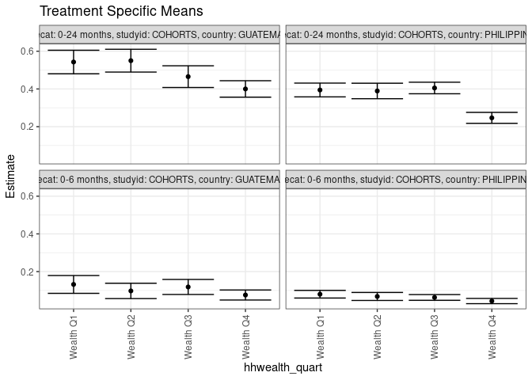

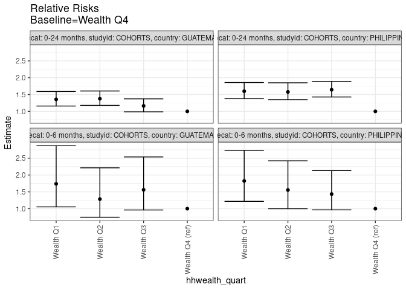

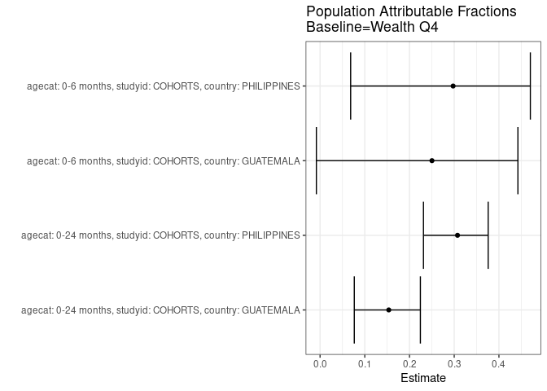

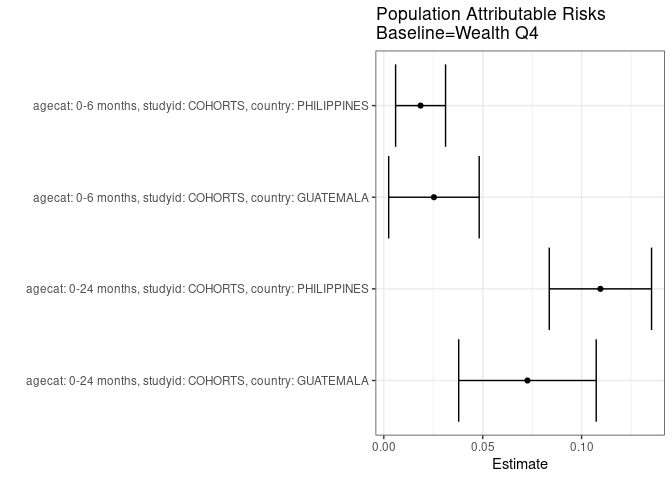

## Results Table

### Parameter: TSM

| agecat | studyid | country | intervention_level | baseline_level | estimate | ci_lower | ci_upper |
| --- | --- | --- | --- | --- | --- | --- | --- |
| 0-24 months | COHORTS | GUATEMALA | Wealth Q4 | NA | 0.4000000 | 0.3563833 | 0.4436167 |
| 0-24 months | COHORTS | GUATEMALA | Wealth Q1 | NA | 0.5428571 | 0.4804544 | 0.6052599 |
| 0-24 months | COHORTS | GUATEMALA | Wealth Q2 | NA | 0.5500000 | 0.4895051 | 0.6104949 |
| 0-24 months | COHORTS | GUATEMALA | Wealth Q3 | NA | 0.4652778 | 0.4076486 | 0.5229069 |
| 0-24 months | COHORTS | PHILIPPINES | Wealth Q4 | NA | 0.2467378 | 0.2176309 | 0.2758448 |
| 0-24 months | COHORTS | PHILIPPINES | Wealth Q1 | NA | 0.3944687 | 0.3579164 | 0.4310211 |
| 0-24 months | COHORTS | PHILIPPINES | Wealth Q2 | NA | 0.3892989 | 0.3482430 | 0.4303548 |
| 0-24 months | COHORTS | PHILIPPINES | Wealth Q3 | NA | 0.4050761 | 0.3744142 | 0.4357381 |
| 0-6 months | COHORTS | GUATEMALA | Wealth Q4 | NA | 0.0759162 | 0.0493427 | 0.1024897 |
| 0-6 months | COHORTS | GUATEMALA | Wealth Q1 | NA | 0.1319797 | 0.0846926 | 0.1792668 |
| 0-6 months | COHORTS | GUATEMALA | Wealth Q2 | NA | 0.0975610 | 0.0569234 | 0.1381985 |
| 0-6 months | COHORTS | GUATEMALA | Wealth Q3 | NA | 0.1185771 | 0.0787214 | 0.1584327 |
| 0-6 months | COHORTS | PHILIPPINES | Wealth Q4 | NA | 0.0438909 | 0.0300601 | 0.0577216 |
| 0-6 months | COHORTS | PHILIPPINES | Wealth Q1 | NA | 0.0800582 | 0.0597616 | 0.1003549 |
| 0-6 months | COHORTS | PHILIPPINES | Wealth Q2 | NA | 0.0682657 | 0.0470300 | 0.0895014 |
| 0-6 months | COHORTS | PHILIPPINES | Wealth Q3 | NA | 0.0629442 | 0.0477750 | 0.0781133 |

### Parameter: E(Y)

| agecat | studyid | country | intervention_level | baseline_level | estimate | ci_lower | ci_upper |
| --- | --- | --- | --- | --- | --- | --- | --- |
| 0-24 months | COHORTS | GUATEMALA | NA | NA | 0.4726135 | 0.4452311 | 0.4999958 |
| 0-24 months | COHORTS | PHILIPPINES | NA | NA | 0.3562316 | 0.3392530 | 0.3732102 |
| 0-6 months | COHORTS | GUATEMALA | NA | NA | 0.1012536 | 0.0828843 | 0.1196229 |
| 0-6 months | COHORTS | PHILIPPINES | NA | NA | 0.0624796 | 0.0538987 | 0.0710604 |

### Parameter: RR

| agecat | studyid | country | intervention_level | baseline_level | estimate | ci_lower | ci_upper |
| --- | --- | --- | --- | --- | --- | --- | --- |
| 0-24 months | COHORTS | GUATEMALA | Wealth Q4 | Wealth Q4 | 1.000000 | 1.0000000 | 1.000000 |
| 0-24 months | COHORTS | GUATEMALA | Wealth Q1 | Wealth Q4 | 1.357143 | 1.1582830 | 1.590144 |
| 0-24 months | COHORTS | GUATEMALA | Wealth Q2 | Wealth Q4 | 1.375000 | 1.1777112 | 1.605338 |
| 0-24 months | COHORTS | GUATEMALA | Wealth Q3 | Wealth Q4 | 1.163194 | 0.9862464 | 1.371890 |
| 0-24 months | COHORTS | PHILIPPINES | Wealth Q4 | Wealth Q4 | 1.000000 | 1.0000000 | 1.000000 |
| 0-24 months | COHORTS | PHILIPPINES | Wealth Q1 | Wealth Q4 | 1.598736 | 1.3760335 | 1.857482 |
| 0-24 months | COHORTS | PHILIPPINES | Wealth Q2 | Wealth Q4 | 1.577784 | 1.3468738 | 1.848281 |
| 0-24 months | COHORTS | PHILIPPINES | Wealth Q3 | Wealth Q4 | 1.641727 | 1.4270152 | 1.888744 |
| 0-6 months | COHORTS | GUATEMALA | Wealth Q4 | Wealth Q4 | 1.000000 | 1.0000000 | 1.000000 |
| 0-6 months | COHORTS | GUATEMALA | Wealth Q1 | Wealth Q4 | 1.738491 | 1.0535020 | 2.868861 |
| 0-6 months | COHORTS | GUATEMALA | Wealth Q2 | Wealth Q4 | 1.285114 | 0.7458453 | 2.214289 |
| 0-6 months | COHORTS | GUATEMALA | Wealth Q3 | Wealth Q4 | 1.561946 | 0.9614134 | 2.537593 |
| 0-6 months | COHORTS | PHILIPPINES | Wealth Q4 | Wealth Q4 | 1.000000 | 1.0000000 | 1.000000 |
| 0-6 months | COHORTS | PHILIPPINES | Wealth Q1 | Wealth Q4 | 1.824029 | 1.2172649 | 2.733245 |
| 0-6 months | COHORTS | PHILIPPINES | Wealth Q2 | Wealth Q4 | 1.555351 | 0.9989080 | 2.421760 |
| 0-6 months | COHORTS | PHILIPPINES | Wealth Q3 | Wealth Q4 | 1.434106 | 0.9644804 | 2.132403 |

### Parameter: PAR

| agecat | studyid | country | intervention_level | baseline_level | estimate | ci_lower | ci_upper |
| --- | --- | --- | --- | --- | --- | --- | --- |
| 0-24 months | COHORTS | GUATEMALA | Wealth Q4 | NA | 0.0726135 | 0.0378532 | 0.1073737 |
| 0-24 months | COHORTS | PHILIPPINES | Wealth Q4 | NA | 0.1094938 | 0.0836436 | 0.1353439 |
| 0-6 months | COHORTS | GUATEMALA | Wealth Q4 | NA | 0.0253374 | 0.0024609 | 0.0482138 |
| 0-6 months | COHORTS | PHILIPPINES | Wealth Q4 | NA | 0.0185887 | 0.0059625 | 0.0312149 |

### Parameter: PAF

| agecat | studyid | country | intervention_level | baseline_level | estimate | ci_lower | ci_upper |
| --- | --- | --- | --- | --- | --- | --- | --- |
| 0-24 months | COHORTS | GUATEMALA | Wealth Q4 | NA | 0.1536424 | 0.0764998 | 0.2243411 |
| 0-24 months | COHORTS | PHILIPPINES | Wealth Q4 | NA | 0.3073668 | 0.2312478 | 0.3759487 |
| 0-6 months | COHORTS | GUATEMALA | Wealth Q4 | NA | 0.2502368 | -0.0082753 | 0.4424690 |
| 0-6 months | COHORTS | PHILIPPINES | Wealth Q4 | NA | 0.2975163 | 0.0683899 | 0.4702899 |